# Module_4_Technique Practice

Ashna Solkar

2025-05-04

# Environment Reset Code

```r
rm(list = ls())
```

# Libraries Used

```r
library(readr)  # For parsing a flat file into a tibble
library(dplyr)  # For data wrangling
library(caret)  # For splitting the data
library(e1071)  # To enable svm()
```

# Loading Dataset

```r
data <- read_csv("Employee_Salaries_2019_to_2024.csv")
str(data)
```

```
## spc_tbl_ [57,075 × 9] (S3: spec_tbl_df/tbl_df/tbl/data.frame)
##  $ Department     : chr [1:57075] "ABS" "CUS" "DGS" "CEX" ...
##  $ Department Name: chr [1:57075] "Alcohol Beverage Services" "Community Use of Public Facilities" "Department of General Services" "Offices of the County Executive" ...
##  $ Division       : chr [1:57075] "ABS 85 IT Administration" "CUS 70 Finance and Administrative Support Team" "DGS 36 Fleet Management Services" "CEX 15 Chief Administrative Officer's Office" ...
##  $ Gender         : chr [1:57075] "M" "F" "F" "F" ...
##  $ Base Salary    : num [1:57075] 169555 141877 87523 207000 91392 ...
##  $ Overtime Pay   : num [1:57075] 0 0 748 0 0 ...
##  $ Longevity Pay  : num [1:57075] 0 0 2701 0 5733 ...
##  $ Grade          : chr [1:57075] "M3" "M3" "16" "EX2" ...
##  $ Year           : num [1:57075] 2024 2024 2024 2024 2024 ...
##  - attr(*, "spec")=
##   .. cols(
##   ..   Department = col_character(),
##   ..   `Department Name` = col_character(),
##   ..   Division = col_character(),
##   ..   Gender = col_character(),
##   ..   `Base Salary` = col_double(),
##   ..   `Overtime Pay` = col_double(),
##   ..   `Longevity Pay` = col_double(),
##   ..   Grade = col_character(),
##   ..   Year = col_double()
##   .. )
##  - attr(*, "problems")=<externalptr>
```

# Converting Variables to Factor

Converting some of these character (chr) and numeric (num) columns to factors using factor() so that R treats them correctly as categorical variables in the model.

```r
data <- data %>%
  mutate(
    Department = factor(Department),
    Gender = factor(Gender),
    Grade = factor(Grade),
    Year = factor(Year)
  )
```

# Creating a New Variable called “Salary Level”

The purpose of creating a new variable is to transform the continuous ‘Base Salary’ data into categorical classes (i.e.; “Low”, “Medium”, “High”) so that Support Vector Machine (SVM) can be used for classification.

```r
summary(data$`Base Salary`)
```

```
##    Min. 1st Qu.  Median    Mean 3rd Qu.    Max.
##    4816   63932   82998   85754  103034  306900
```

Based on the spread of the data of the ‘Base Salary’ variable, we use tertiles to divide the data into three equal-frequency groups using the ntile() function. This ensures a balanced classification across all salary levels.

T1 (0–33.3%) is labeled as “Low” T2 (33.3–66.6%) as “Medium” T3 (66.6–100%) as “High”

This method automatically classifies the salaries into equal-frequency groups

```r
data <- data %>%
  mutate(`Salary Level`= ntile(`Base Salary`,3)) %>%
  mutate(`Salary Level` = factor(`Salary Level`, levels = 1:3,
                                 labels = c("Low", "Medium", "High")))

head(data)
```

| Department | Department Name | Division | Gender | Base Salary | Overtime Pay | Longevity Pay | Grade | Year | Salary Level |
| --- | --- | --- | --- | --- | --- | --- | --- | --- | --- |
| ABS | Alcohol Beverage Services | ABS 85 IT Administration | M | 169555.0 | 0.00 | 0.00 | M3 | 2024 | High |
| CUS | Community Use of Public Facilities | CUS 70 Finance and Administrative Support Team | F | 141876.9 | 0.00 | 0.00 | M3 | 2024 | High |
| DGS | Department of General Services | DGS 36 Fleet Management Services | F | 87523.0 | 748.37 | 2701.48 | 16 | 2024 | Medium |
| CEX | Offices of the County Executive | CEX 15 Chief Administrative Officer's Office | F | 207000.0 | 0.00 | 0.00 | EX2 | 2024 | High |
| HHS | Department of Health and Human Services | HHS 60 Office of Eligibility and Support Services | F | 91392.0 | 0.00 | 5733.27 | N17 | 2024 | Medium |
| OAG | Office of Agriculture | OAG 78 Agricultural Services | F | 108899.0 | 0.00 | 3361.18 | N21 | 2024 | High |

Business Objective: To identify whether gender plays a significant role in determining salary levels across departments and grades

# Splitting the Data

The dataset is split into 70% - 30% for training and testing the data using createDataPartition() from caret package.

createDataPartition() performs stratified sampling. That is, it makes sure that the training and testing sets have a similar mix of salary levels — like the same balance of “Low”, “Medium”, and “High” salaries.

```r
set.seed(123) # For reproducibility
trainIndex <- createDataPartition(data$`Salary Level`, p = 0.70, list = FALSE)
# p = 0.7 gives you 70% training data
# list = FALSE returns a plain vector of row indices. Makes it easier to split data using regular indexing.

# Select rows for training data using the indices from createDataPartition()
train <- data[trainIndex,]

# Use the remaining rows (those not in training) as test data
test <- data[-trainIndex,]
```

# Building SVM Classification Model For Business Objective

We are building SVM classification model using svm() function from e1071 package. ‘Salary Level’ is the target variable and ‘Department’, ‘Gender’, ‘Grade’, and ‘Year’ in the dataset are predictors. Since ‘Salary Level’ is a factor, svm() automatically builds a classification model. The model is learning to classify the ‘Salary Level’ based on the variables - ‘Department’, ‘Gender’, ‘Grade’, and ‘Year’.

```r
# Training the "train" Data
model <- svm(`Salary Level` ~ Department + Gender + Grade + Year,
             data = train)

# Displays basic summary of the model
print(model)
```

```
##
## Call:
## svm(formula = `Salary Level` ~ Department + Gender + Grade + Year,
##     data = train)
##
##
## Parameters:
##    SVM-Type:  C-classification
##  SVM-Kernel:  radial
##        cost:  1
##
## Number of Support Vectors:  26755
```

```r
# Gives detailed info
summary(model)
```

```
##
## Call:
## svm(formula = `Salary Level` ~ Department + Gender + Grade + Year,
##     data = train)
##
##
## Parameters:
##    SVM-Type:  C-classification
##  SVM-Kernel:  radial
##        cost:  1
##
## Number of Support Vectors:  26755
##
##  ( 11330 7698 7727 )
##
##
## Number of Classes:  3
##
## Levels:
##  Low Medium High
```

Similarly, detailed information is given by summary(): The distribution of support vectors across classes: (11330 7698 7727) indicates 11330 for Low, 7698 for Medium, 7727 for High Number of classes: 3 Levels: Names of classes (‘Salary Level’)

```r
# Testing on "test" data
pred <- predict(model, test)
```

Testing model on “test” data to evaluate how well it predicts on to new, unseen data.

```r
# Checking accuracy
table(Predicted = pred, Actual = test$`Salary Level`)
```

```
##          Actual
## Predicted  Low Medium High
##    Low    3615    368    3
##    Medium 1862   4175  910
##    High    230   1164 4794
```

The above command creates a confusion matrix, which compares: Predicted = the Salary Levels predicted by SVM model Actual = the Salary Levels actually observed in the test data

Output: Model was able to predict true positive values in majority, but false negatives and false positives exists too. Example, when the Salary Level was actually Low, model correctly predicted for 3615 records, but incorrectly predicted as Medium for 1862 records and High for 230 records.

Similarly, when the Salary Level was actually Medium, model correctly predicted for 4175 records, but incorrectly predicted as Low for 368 records and High for 1164 records.

And, when the Salary Level was actually High, model correctly predicted for 4794 records, but incorrectly predicted as Low for 3 records and Medium for 910 records.

```r
# Using Decision Values

deci <- predict(model, test, decision.values = TRUE)
attr(deci, "decision.values")[1:10,] # Gets attributes of the object deci
```

```
##    Medium/High Medium/Low   High/Low
## 1   -1.0396336  0.4851740  1.0310507
## 2   -1.0669660  0.5502341  1.0736103
## 3    0.2929423  1.0106144  1.0281916
## 4   -1.0613127  0.4859210  1.0343355
## 5   -1.0504004  0.6680813  1.1035602
## 6    0.2484143  1.0265988  1.1299123
## 7    0.8730194  1.0192029  1.0094578
## 8   -1.1292942  0.2382451  1.2535824
## 9    0.9868926  0.7436251 -0.9659516
## 10   0.9996884  0.7369522 -1.0048443
```

Here we are exploring decision values, which show how confident the SVM is about its predictions for a given employee, based on factors like Gender, Grade, Department, and Year. We’re telling the SVM to not only predict class labels for the test data, but also to return the underlying decision values. These values represent the distance of each point from the decision boundaries that separate the classes. In a multi-class SVM (like this one with 3 levels), the model creates one decision function per pair of classes using the “one-vs-one” approach.

Output Interpretation: The label Medium/High means: Medium is the first class, and High is the second class.

If the decision value is positive: The model is leaning toward the first class

If the decision value is negative: The model is leaning toward the second class.

The higher the absolute value, the stronger the confidence in that direction.

Each row = one observation in test data Each column = one pairwise class comparison

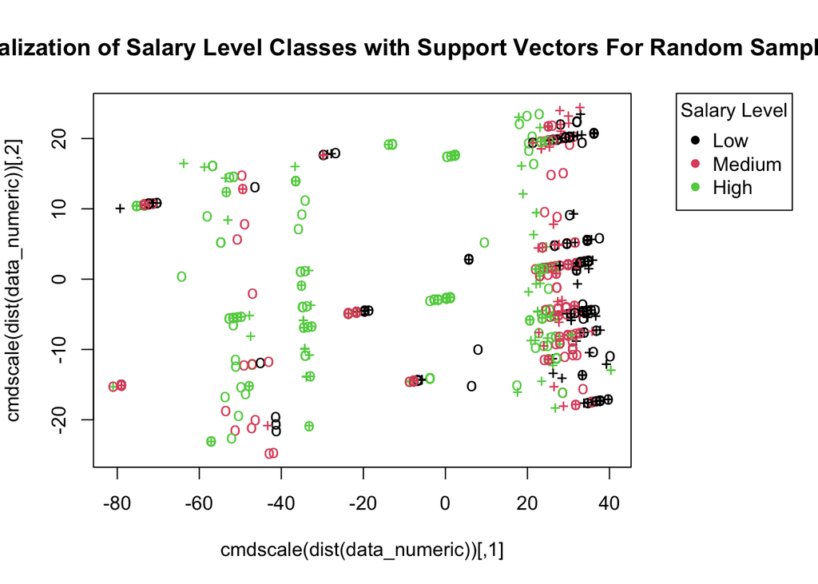

```r
# Using random sample data for visualization
set.seed(100)
sample_rows <- sample(nrow(data), 1000)
# Creating subset of data
sample_data <- data[sample_rows, ]

# Converting predictors to numeric
data_numeric <- sample_data %>%
  select(Department, Gender, Grade, Year) %>%
  mutate(across(everything(), ~ as.numeric(as.factor(.))))

# Visualizing Classes by Color

# Set layout to make room for legend on the right
par(xpd = TRUE, mar = c(5, 4, 4, 8))  # Increasing right margin for legend placement
plot(cmdscale(dist(data_numeric)),
     col = as.integer(sample_data$`Salary Level`),
     pch = ifelse(sample_rows %in% model$index, "+", "o"),
     main = "SVM Visualization of Salary Level Classes with Support Vectors For Random Sample")
legend("topright", inset = c(-0.3, 0), legend = c("Low", "Medium", "High"),
       col = 1:3, pch = 16, title = "Salary Level")
```

Circles (o) are normal observations. Crosses (+) are support vectors — these are the critical observations the SVM uses to draw the decision boundary.

The SVM visualization shows significant overlap between Low, Medium, and High salary levels based on the current predictors. This suggests that employee salary levels cannot be easily separated using only Department, Gender, Grade, and Year. The high density of support vectors confirms that many observations lie near the classification boundary, making it difficult for the model to achieve high accuracy.

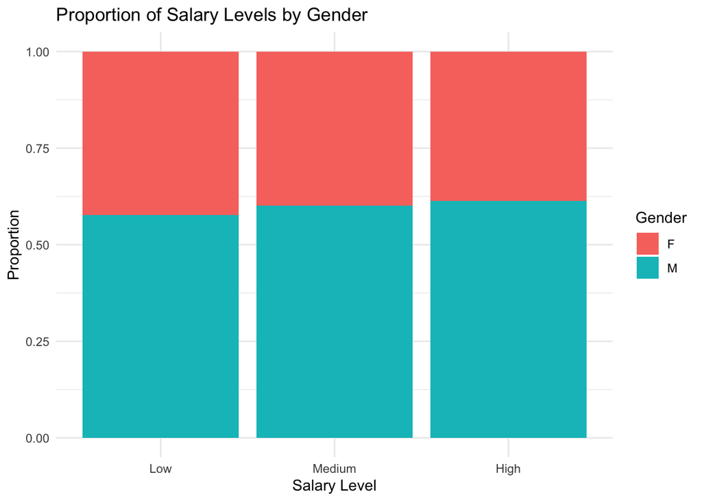

```r
ggplot(data, aes(x = `Salary Level`, fill = Gender)) +
  geom_bar(position = "fill") +
  labs(y = "Proportion", title = "Proportion of Salary Levels by Gender") +
  theme_minimal()
```

```r
table(data$`Salary Level`, data$Gender)
```

```
##
##              F     M
##   Low     8058 10967
##   Medium  7587 11438
##   High    7354 11671
```

```r
prop.table(table(data$`Salary Level`, data$Gender), margin = 1)
```

```
##
##                  F         M
##   Low    0.4235480 0.5764520
##   Medium 0.3987911 0.6012089
##   High   0.3865440 0.6134560
```

As salary level increases, the proportion of female employees decreases, while male representation increases. High salary tier is more male-dominated than Low and Medium.

# SVM Model without Gender

```r
# Training on "train" data
model_without_gender <- svm(`Salary Level` ~ Department + Grade + Year,
             data = train)

summary(model_without_gender)
```

```
##
## Call:
## svm(formula = `Salary Level` ~ Department + Grade + Year, data = train)
##
##
## Parameters:
##    SVM-Type:  C-classification
##  SVM-Kernel:  radial
##        cost:  1
##
## Number of Support Vectors:  26672
##
##  ( 11280 7689 7703 )
##
##
## Number of Classes:  3
##
## Levels:
##  Low Medium High
```

```r
# Testing on "test" data
pred_withoutgender <- predict(model_without_gender, test)

# Checking accuracy
table(Predicted = pred_withoutgender, Actual = test$`Salary Level`)
```

```
##          Actual
## Predicted  Low Medium High
##    Low    3615    368    3
##    Medium 1862   4175  910
##    High    230   1164 4794
```

The SVM model was able to classify salary levels just as well without using gender.

So, gender does not add predictive value for the model, given the other features (Department, Grade, and Year)

```r
prop.table(table(data$Gender))
```

```
##
##        F        M
## 0.402961 0.597039
```

Density estimation for Gender and Base Salary

Do men and women have different salary distributions?

Modeling the salary structure for males only using one-class SVM, and then anticipating how many females fall outside that structure, that could highlight disparity

```r
# Fit one-class SVM on male employees
male_data <- data %>% filter(Gender == "M") %>%
  select(`Base Salary`, Grade, Department) %>%
  mutate(across(everything(), ~ as.numeric(as.factor(.))))

svm_male <- svm(male_data, type = "one-classification", kernel = "radial")

# Predict for females
female_data <- data %>% filter(Gender == "F") %>%
  select(`Base Salary`, Grade, Department) %>%
  mutate(across(everything(), ~ as.numeric(as.factor(.))))

pred_female <- predict(svm_male, female_data)
table(pred_female)
```

```
## pred_female
## FALSE  TRUE
## 16233  6766
```

When modeling salary patterns using only male employees, we find that over 70% of female employees fall outside that distribution. This could mean that women are systematically assigned to different roles or salary bands than men, reinforcing concerns about gender-based disparities in compensation structure.

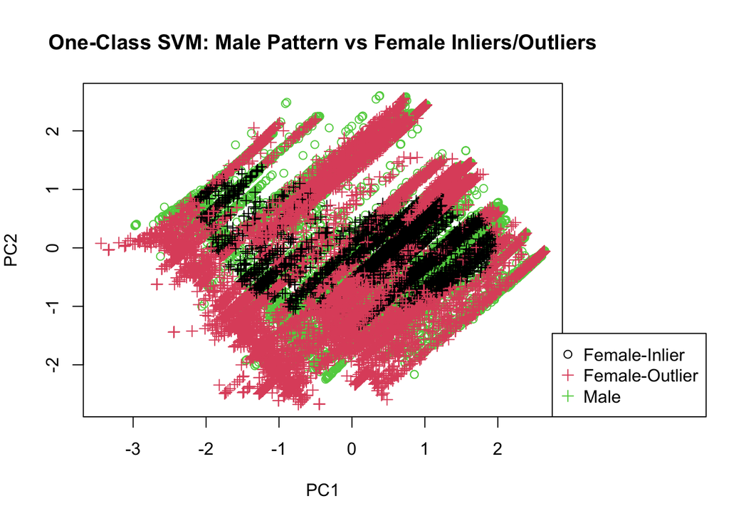

```r
male_data_labeled <- male_data %>% mutate(Group = "Male")
female_data_labeled <- female_data %>%
  mutate(Group = ifelse(pred_female, "Female-Inlier", "Female-Outlier"))

combined <- rbind(male_data_labeled, female_data_labeled)

pca <- prcomp(combined %>% select(-Group), scale. = TRUE)

par(xpd = TRUE, mar = c(5, 4, 4, 8))
plot(pca$x[, 1:2],
     col = as.factor(combined$Group),
     pch = ifelse(combined$Group == "Male", 1, 3),
     xlab = "PC1", ylab = "PC2",
     main = "One-Class SVM: Male Pattern vs Female Inliers/Outliers")
legend("bottomright",inset = c(-0.3, 0), legend = levels(as.factor(combined$Group)),
       col = 1:3, pch = c(1, 3, 3))
```

Male (green circles) These points represent the pattern learned by the one-class SVM. This forms the “normal” salary structure the model understands.

Female-Outlier (red plus signs) These are female employees whose salary–grade–department structure deviates from the male pattern. A large number of these suggests women are structurally placed differently (lower grade, lower base pay, or different department alignment).